# PA1_template.Rmd

jspp

10/12/2014

# 1-Loading and Tranforming Data

### 1.1- Loading data, including download

data is downloaded in zip format, then extracted and then read into R

```r
download.file("http://d396qusza40orc.cloudfront.net/repdata%2Fdata%2Factivity.zip",
              "represearch/factivitydata.zip")
unzip("represearch/factivitydata.zip", exdir = "represearch/.")
activitydata <- (read.csv("represearch/activity.csv"))
```

### 1.2- Transforming dates into date format

initially dates are read as factor, here the class is changed

```r
activitydata$date <- as.Date (activitydata$date)
```

# 2 Total Number of Steps every Day

generates a variable that states the total steps, mean steps(by 5 min interval) and the number of missing values every day

```r
daily.steps.calc <- function()  {
    total.steps <- tapply(activitydata$steps, activitydata$date, sum, na.rm = TRUE)
    step.means <- tapply(activitydata$steps, activitydata$date, mean, na.rm = TRUE)
    NA.count <- sapply(tapply(activitydata$steps, activitydata$date, is.na,
                              simplify = FALSE),sum, simplify = TRUE)
    daily.steps <<- as.data.frame(cbind(total.steps, step.means, NA.count))
}
daily.steps.calc()
```

## 2.1 Histogram

loads ggplot2 and plots the histogram

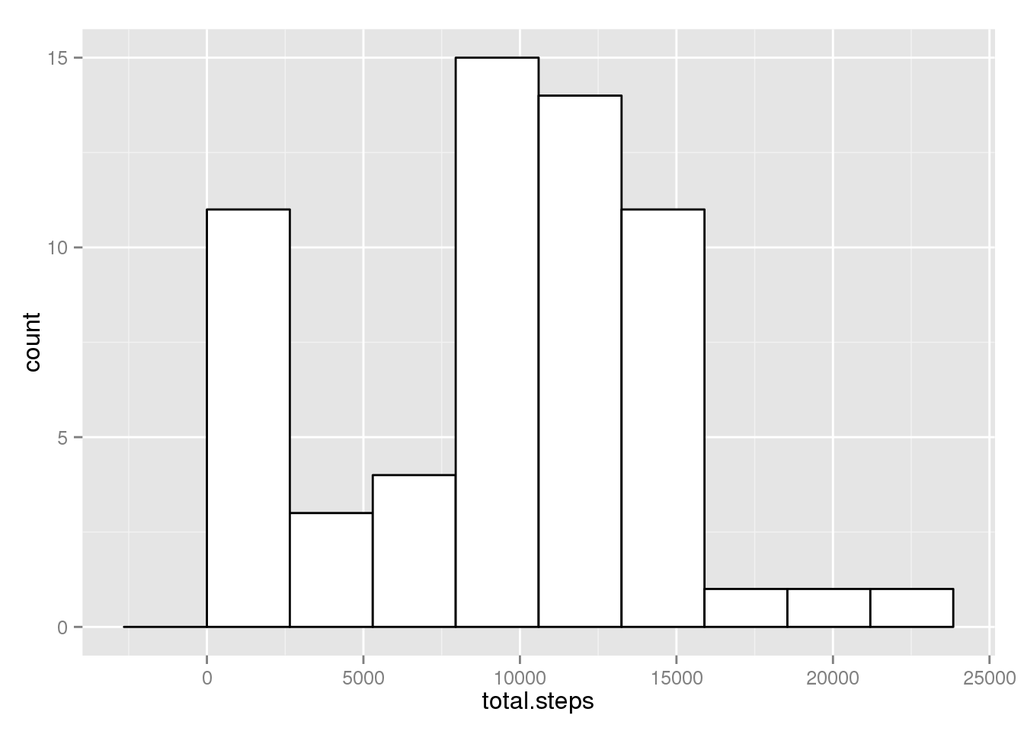

```r
library(ggplot2)
ggplot(daily.steps, aes (x=total.steps)) +
        geom_histogram(binwidth = (max(daily.steps$total.steps)/8),
        colour = "black", fill= "white")
```

### 2.2 Mean and median

reports Mean, median and a couple of extra things for the total steps every day

```r
summary(daily.steps$total.steps)
```

```
##    Min. 1st Qu.  Median    Mean 3rd Qu.    Max.
##       0    6778   10400    9354   12810   21190
```

# 3 Average number of Steps per 5 min Interval

### Calculating the averages

```r
steps.interval <- as.data.frame(tapply(activitydata$steps, activitydata$interval,
                         mean, na.rm = TRUE))
steps.interval <- cbind(as.numeric(rownames(steps.interval)),steps.interval)
colnames(steps.interval) <- c("Interval","Mean.Steps.in.Interval")
```

### plot

once aggain ggplot2 is loaded and the plot is generated

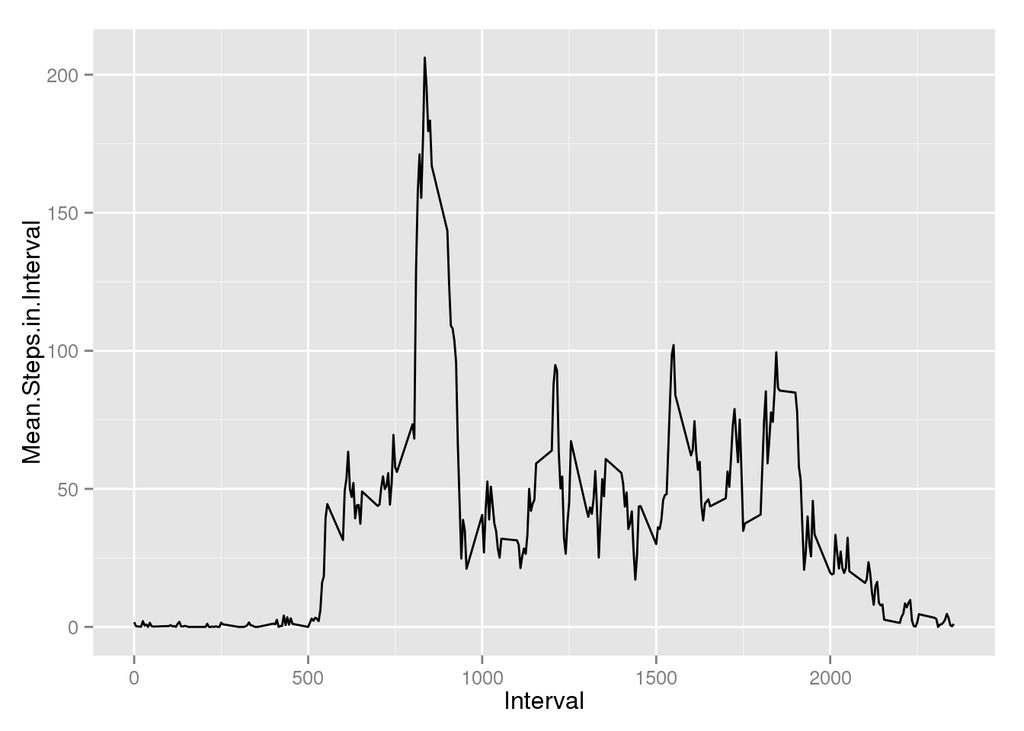

```r
library(ggplot2)
g <- ggplot(steps.interval , aes(Interval,Mean.Steps.in.Interval))
g + geom_line()
```

### maximum

reports the maximum

```r
steps.interval[which.max(steps.interval$Mean.Steps.in.Interval),]
```

```
##     Interval Mean.Steps.in.Interval
## 835      835               206.1698
```

# 4 Missing Values

### 4.1 SumNA’s

sums all the NA values we calculated before, in section 2

```r
sum(daily.steps$NA.count)
```

```
## [1] 2304
```

Since data missing corresponds to complete days one cannot fill thw data with estimates from the day, therefor the approach whould be using the mean for the 5 min Interval form other values

### 4.2 Filling data in new dataset

a copy of the data is generated, then means by each interval are calculated, finaly taking means for the respective interval data is filled in the NA spaces

```r
activitydatafill <- activitydata
activitydatafill$steps[is.na(activitydata$steps)] <-
        (tapply(activitydata$steps, activitydata$interval,mean, na.rm = TRUE))[
        as.factor(activitydata$interval[is.na(activitydata$steps)])]
```

### 4.3 Total Number of Steps every Day

Equivalent to section 2 with the filled data

```r
daily.steps.calc.fill <- function()  {
    total.steps <-  tapply(activitydatafill$steps,
                            activitydatafill$date, sum, na.rm = TRUE)
    step.means <-   tapply(activitydatafill$steps,
                            activitydatafill$date, mean, na.rm = TRUE)
    NA.count <- sapply(tapply(activitydatafill$steps, activitydatafill$date,
                              is.na, simplify = FALSE),sum, simplify = TRUE)
    daily.steps.fill <<- as.data.frame(cbind(total.steps, step.means, NA.count))
}
daily.steps.calc.fill()
```

### 4.4 -Makes Histogram

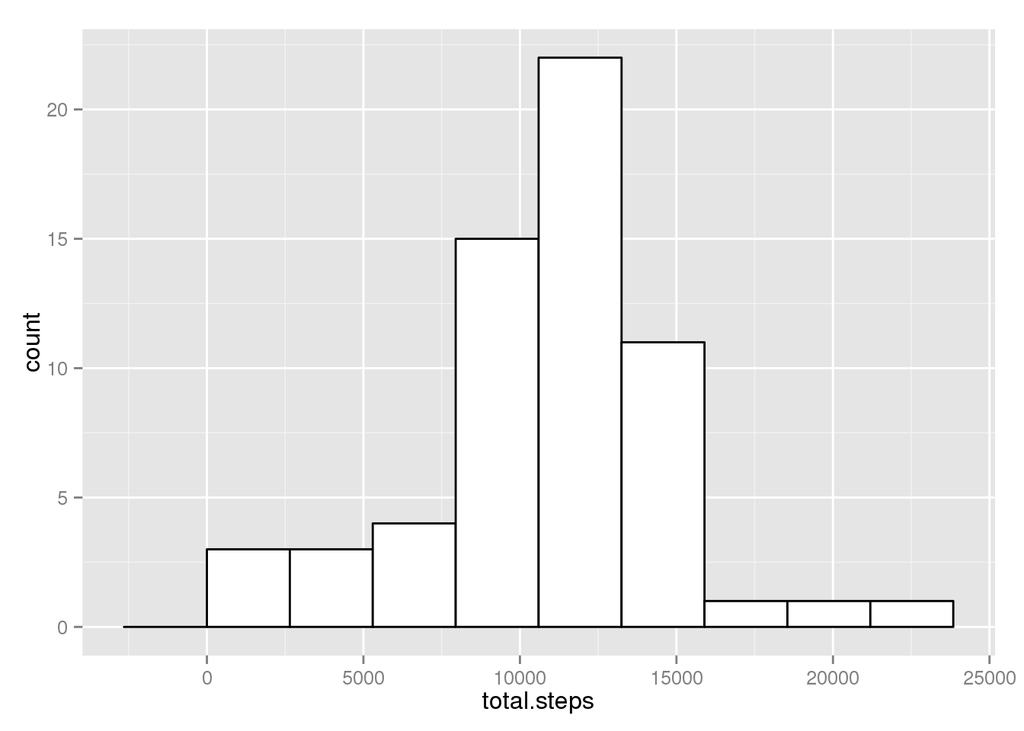

```r
library(ggplot2)
ggplot(daily.steps.fill, aes (x=total.steps)) +
    geom_histogram(binwidth = (max(daily.steps.fill$total.steps)/8),
                   colour = "black", fill= "white")
```

### 4.5 reports mean, median and a couple of extra things

```r
summary(daily.steps.fill$total.steps)
```

```
##    Min. 1st Qu.  Median    Mean 3rd Qu.    Max.
##      41    9819   10770   10770   12810   21190
```

compare with the data obtained without filling

```r
summary(daily.steps$total.steps)
```

```
##    Min. 1st Qu.  Median    Mean 3rd Qu.    Max.
##       0    6778   10400    9354   12810   21190
```

it is possible to see there are differences in the two data sets looking at the mean, minimum value and 1st quartile.

# 5 Weekday-Weekend difference

### 5.1 Addition of extra factor column

a collumn “weekday” is added with the factors “weekday” and “weekend” to state if the corresponding interval occurs on a weekday or a weekend

```r
weekdayaddition <- function() {
    tweekdays <- c("Monday","Tuesday","Wednesday","Thursday","Friday")
    tweekends <- c("Saturday","Sunday")
    weekday <- weekdays(activitydatafill$date)
    weekday[weekday %in% tweekdays] <- "weekday"
    weekday[weekday %in% tweekends] <- "weekend"
    activitydatafill <<- cbind(activitydatafill, weekday)
}
weekdayaddition()
```

### 5.2 Plot Grid between weekdays and weekends interval mean

First data is separated insto weekdays and weekends, then means are calculated and finally data is merged aggain to be exported to the global environment

Then ggplo2 is loaded and the graph is generated

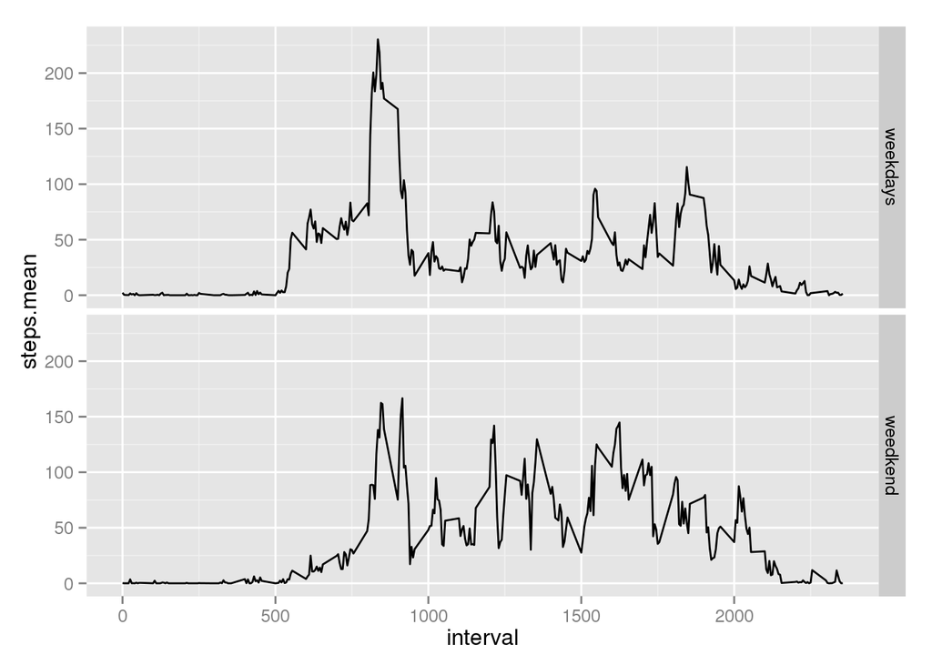

```r
interval.mean.by.weekday <- function() {
    weekdays <- activitydatafill[activitydatafill$weekday == "weekday",]
    weekends <- activitydatafill[activitydatafill$weekday == "weekend",]
    step.inter.fill.wd <- tapply(weekdays$steps,weekdays$interval, mean)
    step.inter.fill.wd <- data.frame(step.inter.fill.wd,
                                     as.numeric(rownames(step.inter.fill.wd)),
                                     "weekdays")
    step.inter.fill.ed <- tapply(weekends$steps,weekends$interval, mean)
    step.inter.fill.ed <- data.frame(step.inter.fill.ed,
                                     as.numeric(rownames(step.inter.fill.ed)),
                                     "weedkend")
    colnames(step.inter.fill.wd)<-c("steps.mean", "interval","weekday")
    colnames(step.inter.fill.ed)<-c("steps.mean", "interval","weekday")
    step.inter.fill.wd$step<-as.numeric(step.inter.fill.wd$step)
    step.inter.fill.ed$step<-as.numeric(step.inter.fill.ed$step)
    intervalmeans <<- rbind(step.inter.fill.wd,step.inter.fill.ed)
}
interval.mean.by.weekday()

library(ggplot2)
pg <- ggplot(intervalmeans, aes(x = interval, y = steps.mean))+
          geom_line() + facet_grid(weekday ~ .)
pg
```